# Przepływ odwiedzających przez wystawę Re: generacja

Grupa CT

24 kwietnia 2016

# Spis treści

1. Biblioteka `CNK`
2. Aplikacja
3. Server i ui

## Biblioteka `CNK`

Po wczytaniu wszystkich danych zajęliśmy się budową macierzy prawdopodobieństw przejścia. Funkcja obliczająca prawdopodobieństwa jest w pakiecie pod nazwą `pstwa.przejscia`.

# pstwa.przejscia

```r
#' Funkcja obliczająca macierz prawdopodobieństw przejscia
#'
#' Funkjca oblicza macierz prawdopodobieństw przejścia w jednym kroku z jednego
#' eksponatu do drugiego dla każdej pary eksponatów. Dane są wczytywane z bazy
#' SQLite znajdującej się w pliku baza i zapisywane są do pliku .rda o nazwie
#' wyjscie.
#'
#' @param baza Ścieżka do wejściowej bazy SQLitowej.
#' @param wyjscie Sciezka do pliku wyjściowego.
#' @return NULL
#' @import RSQLite
#' @import dplyr
#' @import magrittr
#' @export
#'
#'


pstwa.przejscia <- function(baza, wyjscie = "pstwa.rda") {

    db <- dbConnect(SQLite(), baza)
    dane <- dbReadTable(db, "interakcje")
    dbDisconnect(db)

    dane$poczatek <- strptime(dane$poczatek, '%Y-%m-%d %H:%M:%S')


    # sortowanie w grupach
    dane %>% group_by(dzien = as.Date(poczatek), gosc) %>%
        arrange(poczatek) -> dane


    eks <- unique(dane$eksponat)

    n <- nrow(dane)

    # ostatni eksponat w scieżce
    dane$ostatni <- c(dane$gosc[-n] != dane$gosc[-1], 1)


    # zlicza dla kazdej pary eksponatow (e1, e2) ile razy e2 był w sciezce po e1
    tabela <- table(dane$eksponat[-n], dane$eksponat[-1],
                    dane$ostatni[-n])[,,1]

    licznosci <- table(dane$eksponat, dane$ostatni)[,1]


    pstwa <- tabela / licznosci

    save(pstwa, file = wyjscie)

    invisible()
}
```

Poniżej przedstawię kod funkcji potrzebnych do rysowania wykresów słupkowych. #wykres

```r
#' Funkcja rysuje wykres prawdopodobieństw przejścia dla danego eksponatu cnk.
#'
#' Rysuje wykres słupkowy prawdopodobieństw przejścia z danego eksponatu do
#' innych eksponatów cnk.
#'
#' @param eksponaty Eksponaty bliskie do "wybranyEksponat".
#' @param wybranyEksponat Eksponat, dla którego chcemy zonaczyć wykres
#' prawdopodobieństw przejścia do innych eksponatów cnk.
#' @return NULL
#' @import ggplot2
#' @export
#'

wykres <- function(eksponaty, wybranyEksponat) {
  tab <- data.frame(eksponaty, names(eksponaty))
  colnames(tab) <- c("pstwo", "nazwa")
  ggplot(tab, aes(factor(nazwa, levels = nazwa), pstwo)) +
    geom_bar(stat = "identity") +
    xlab("eksponat") +
    ylab("prawdopodobienstwo") +
    ggtitle(paste("Prawdopodobieństwa przejścia dla eksponatu",
                  wybranyEksponat))
}
```

Poniżej przedstawię kod funkcji potrzebnych do rysowania map, które zostały dodane do pakietu *cnk*.

# rysuj.mape

Rysuje mapę cnk (bez zaznaczonych eksponatów).

```r
#' Funkcja rysuje mapę cnk.
#'
#' Rysuje mapę cnk (bez zaznaczonych eksponatów).
#'
#' @param img Obrazek w postaci obiektu array wczytany funkcją readPNG z pakietu png.
#' @param srodowisko Środowisko, w którym przechowywane są zmienne globalne
#' dla bieżącej sesji aplikacji.
#' @import png
#' @return NULL
#'

rysuj.mape <- function(img, srodowisko) {
  par(mar = c(0,0,0,0))
  plot(x=1:2, y=1:2, type='n', asp = 1)
  usr <- par()$usr
  assign("usr", usr, envir = srodowisko)
  rasterImage(img, usr[1], usr[3], usr[2], usr[4])
}
```

# mapka1

Funkcja rysuje mapę cnk. Wybrany eksponat zaznacza kolorem niebieskim, bliskie eksponaty kolorem czarnym, a pozostałe kolorem szarym.

```r
#' Funkcja rysuje mapę cnk
#'
#' Rysuje mapę cnk. Wybrany eksponat zaznacz kolorem niebieskim, bliskie eksponaty
#' kolorem czarnym, a pozostałe kolorem szarym.
#'
#' @param wybrany Numer id wybranego eksponatu.
#' @param bliskie Numery id punktów bliskich do wybranego.
#' @param eksponaty Numery id wszystkich ekponatów.
#' @param wspX Współrzędne x wszystkich eksponatów.
#' @param wspY Współrzędne y wszystkich eksponatów.
#' @param img Obrazek w postaci obiektu array wczytany funkcją readPNG z pakietu png.
#' @param srodowisko Środowisko, w którym przechowywane są zmienne globalne
#' dla bieżącej sesji aplikacji.
#' @param usr Parametr usr zwracany przez funkcję par().
#' @return NULL
#' @export
#'

mapka1 <- function(wybrany, bliskie, eksponaty, wspX, wspY, img, srodowisko, usr) {
  rysuj.mape(img, srodowisko)

  nowyUklad <- zamien.uklad(wspX, wspY, 663, 651, usr)
  noweX <- nowyUklad[[1]]
  noweY <- nowyUklad[[2]]

  points(noweX[eksponaty], noweY[eksponaty],
         pch = 19, cex = 0.8, col = "#777777")

  for (b in seq_along(bliskie)) {
    if (rev(bliskie)[b] != wybrany)
      zaznacz.eksponat(rev(bliskie)[b], noweX, noweY,
                       cex = 3*b/length(bliskie))
  }

  zaznacz.eksponat(wybrany, noweX, noweY, cex = 3, col = "blue")
}
```

# generuj.sciezke

Dana funkcja generuje ścieżki na podstawie macierzy przejśc.

```r
#' Funkcja generuje ścieżkę odwiedzanych eksponatów cnk.
#'
#' Generuje ścieżkę odwiedzanych eksponatów cnk na podstawie macierzy przejścia
#'  w kolejnych krokach.
#'
#' @param first Numer id pierwszego eksponatu w ścieżce.
#' @param l Pożądana długość generowanej ścieżki.
#' @param mat Macierz prawdopodobieństw przejścia
#' @return sciezka Ścieżka dlugości "l" od eksponatu "first".
#' @export
#'

generuj.sciezke <- function(first, l, mat){
  sciezka <- vector("numeric", l)
  names(first) <- first

  for(i in 1:l){
    sciezka[i] <- first
    mat[, names(first)] <- -1
    first <- names(which.max(mat[first, ]))
    names(first) <- first
  }

  sciezka
}
```

Mając wygenerowane ścieżki i narysowaną mapkę, możemy nanieść dane ścieżki na mape za pomocą kolejnej funkcji.

# mapka2

```r
#' Funkcja rysuje mapę cnk z zaznaczonymi ścieżkami.
#'
#' Rysuje mapę cnk z zaznaczonymi ścieżkami dojścia z wybranego eksponatu.
#'
#' @param wybrany Numer id eksponatu, od którego zaczyna się scieżka.
#' @param sciezka Wektor id eksponatów znajdującyh się na ścieżkę.
#' @param eksponaty Numery id wszystkich eksponatów.
#' @param wspX Współrzędne x eksponatów.
#' @param wspY Współrzędne y eksponatów.
#' @param img Obrazek w postaci obiektu array wczytany funkcją readPNG z pakietu png.
#' @param srodowisko Środowisko, w którym przechowywane są zmienne globalne
#' dla bieżącej sesji aplikacji.
#' @param usr Parametr usr zwracany przez funkcję par().
#' @return NULL
#' @import shape
#' @export
#'

mapka2 <- function(wybrany, sciezka, eksponaty, wspX, wspY, img, srodowisko, usr) {

  rysuj.mape(img, srodowisko)

  nowyUklad <- zamien.uklad(wspX, wspY, 663, 651, usr)

  noweX <- nowyUklad[[1]]
  noweY <- nowyUklad[[2]]

  points(noweX[eksponaty], noweY[eksponaty],
         pch = 19, cex = 0.8, col = "#777777")

  for (i in seq_along(sciezka)) {
    zaznacz.eksponat(sciezka[i], noweX, noweY, cex = 1.2)
  }

  x <- noweX[names(noweX) %in% sciezka]
  ns <- factor(names(x), sciezka, ordered = TRUE)
  nsc <- as.integer(ns)
  x <- x[order(nsc)]
  y <- noweY[names(noweY) %in% sciezka]
  y <- y[order(nsc)]

  arr.length <- 0.4

  roznX <- (x[-length(sciezka)] - x[-1])
  roznY <- (y[-length(sciezka)] - y[-1])

  Arrows(x[-length(sciezka)],
         y[-length(sciezka)],
         x[-1] +0.07 * (x[-length(sciezka)] - x[-1]),
         y[-1] +0.07 * (y[-length(sciezka)] - y[-1]),
         code = 2,
         arr.length = 0.3,
         arr.width = arr.length/2, arr.adj = 0.5, arr.type = "curved",
         segment = TRUE)
}
```

Więcej funkcji znajduje się w pakiecie `cnk`.

## Aplikacja

Na podstawie danych o prawdobodobieństwach przejść zrobiliśmy za pomocą pakietu `Shiny` aplikację, która ma możliwości takie jak:

### informacje o danych eksponatach

Po wybraniu w lewym panelu eksponatu oraz ustaleniu ilości otrzymujemy tablicę z największym prawdopodobieństwem przejścia w następnym kroku do następnych eksponatów. Również mamy pełne nazwy tych eksponatów.

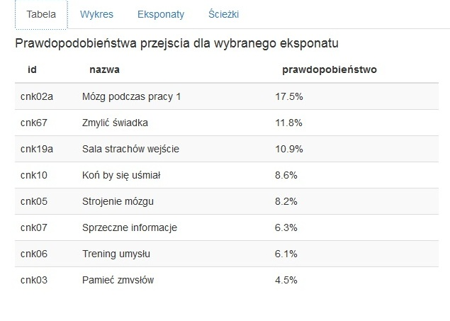

### wykres słupkowy prawdobodobieństw

Dane, które przedstawiają prawdopodobieństwa, ilustrowane za pomocą wykresów słupkowych. Również klikając na dowolny słupek, otrzymujemy nowy wykres słupkowy, dla klikniętego eksponatu.

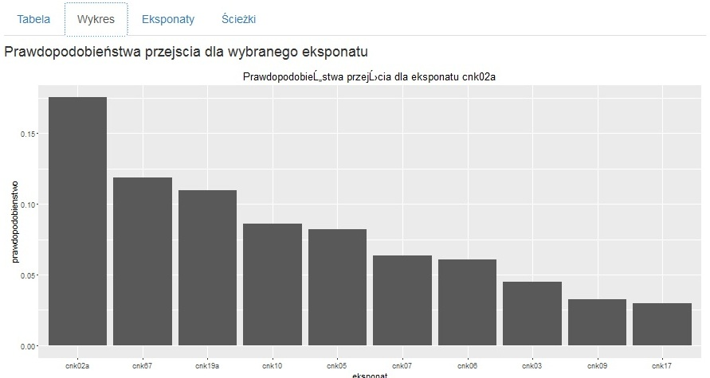

### wizualizacje najbliższych popularnych eksonatów

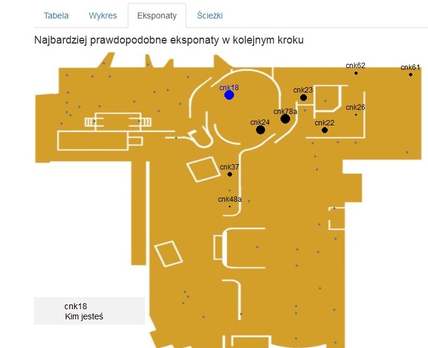

### wizualizacje ścieżki na mapie eksponatów

Napisana została funkcja generująca typową ścieżkę rozpoczynającą się w danym eksponacie na podstawie macierzy zawierającej prawdopodobieństwa przejścia w ten sposób, że jeżeli eksponat pojawił się na ścieżce, to w macierzy nadane zostaje zerowe prawdopodobieństwo w kolejnym kroku i na podstawie nowo otrzymanej macierzy generowana jest dalsza ścieżka.

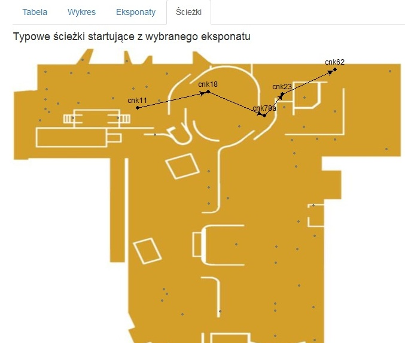

## Server i ui

Dla urochomienia aplikacji niezbędny jest plik `server.R`. Oto `server.R`.

```r
library(cnk)
library(scales)
shinyServer(function(input, output, session) {

    # Zmienne globalne:
    usr <- NULL   # parametr usr zwracany przez funkcję par()
    cala_sciezka <- NULL
    srodowisko <- environment()


    bliskieEskponaty <- reactive({
        sort(pstwa[input$wybranyEksponat, ], decreasing = TRUE)[1:input$suwak]
    })

    # Zakładka tabela
    output$Tabela = renderDataTable({
        eksponaty <- bliskieEskponaty()
        tab <- data.frame(names(eksponaty),
                          pelne_nazwy[names(eksponaty)], percent(eksponaty))
        colnames(tab) <- c("id","nazwa","prawdopobieństwo")
        tab
    }, options = list(searching=FALSE, paging = FALSE, dom = 'ft', ordering = FALSE))


    # Zakładka wykres
    output$wykres = renderPlot({
        wykres(bliskieEskponaty(), input$wybranyEksponat)
    })

    observeEvent(input$klik, {
        reaguj.wykres(bliskieEskponaty(), input$klik, session)
    })


    # Zakładka eksponaty
    output$mapa <- renderPlot({
      mapka1(input$wybranyEksponat, names(bliskieEskponaty()), eksponaty,
             wspX, wspY, img, srodowisko, usr)
      dodaj_info(input$wybranyEksponat,pelne_nazwy[input$wybranyEksponat])
    })


    observeEvent(input$klik_mapa, {
        reaguj.mapa(eksponaty, input$klik_mapa, wspX, wspY,
                     srodowisko, session, usr)
    })


    # Zakładka scieżki
    observeEvent(input$wybranyEksponat, {
        cala_sciezka <<- generuj.sciezke(input$wybranyEksponat, 45, pstwa)
    })


    output$mapa2 <- renderPlot({
        wybrany <- input$wybranyEksponat
        sciezka <- cala_sciezka[1:input$suwak]
        mapka2(wybrany, sciezka, eksponaty, wspX, wspY, img, srodowisko, usr)
    })

    observeEvent(input$klik_mapa2, {
        reaguj.mapa(eksponaty, input$klik_mapa2, wspX, wspY,
                    srodowisko, session, usr)
    })

})
```

Zaś kod `ui.r` wygląda następująco:

```r
library(shiny)
library(cnk)

eksponaty <- rownames(pstwa)

shinyUI(fluidPage(
  tags$head(tags$style(HTML("
                            .well {
                            width: 300px;
                            }
                            "))),
  titlePanel("Przepływ odwiedzających przez wystawę Re: generacja"),
  h5("Grzegorz Bajor, Aleksandr Panimash, Michał Restak, Michał Stolarczyk"),
  br(),
  sidebarLayout(
    sidebarPanel(
      selectInput("wybranyEksponat",
                  label = "Wybierz eksponat",
                  choices = eksponaty,
                  selected = "cnk02a"),
      sliderInput("suwak", "Wybierz liczbę eksponatów",
                  min = 1, max = 45, value = 10, step = 1),

      conditionalPanel('input.dataset === "Tabela"',
                       p("Tabela przedstawia prawdopobieństwa przejścia w jednym kroku
                         z wybranego urządzenia"),
                       p("Suwakiem można zmienić liczbę wyświetlanych najprawdopodobniejszych eksponatów")
      ),
      conditionalPanel('input.dataset === "Wykres"',
                       p("Wykres przedstawia prawdopodobieństwa przejścia w jednym kroku
                         z wybranego urządzenia"),
                       p("Po kliknięciu na słupek zostaniemy przekierowani do kolejnego eksponatu"),
                       p("Suwakiem można regulować liczbę wyświetlanych eksponatów")
      ),
      conditionalPanel('input.dataset === "Eksponaty"',
                       p("Punkty na mapie reprezentują umiejscowienie eksponatu"),
                       p("Wielkość punktów odzwierciedla częstość przejścia z wybranego eksponatu do kolejnego"),
                       p("W lewym dolnym rogu mapy wyswietla się pełna nazwa wybranego eksponatu"),
                       p("Po naciśnięciu punktu zostaniemy przekierowani do kolejnego eksponatu"),
                       p("Suwakiem można regulować liczbę wyróżnionych najpopularniejszych eksponatów")
      ),
      conditionalPanel('input.dataset === "Ścieżki"',
                       p("Punkty na mapie reprezentują umiejscowienie eksponatu"),
                       p("Na mapie znajduje się typowa ścieżka startująca z wybranego eksponatu"),
                       p("Po naciśnięciu punktu zostaniemy przekierowani do kolejnego eksponatu"),
                       p("Suwakiem można regulować długość ścieżki")
      )
    ),
    mainPanel(
      tabsetPanel(

        id = 'dataset',

        tabPanel("Tabela",
                 h4("Prawdopodobieństwa przejscia dla wybranego eksponatu"),
                 dataTableOutput("Tabela")),
        tabPanel("Wykres",
                 h4("Prawdopodobieństwa przejscia dla wybranego eksponatu"),
                 plotOutput("wykres", click = "klik")),
        tabPanel("Eksponaty",
                 h4("Najbardziej prawdopodobne eksponaty w kolejnym kroku"),
                 plotOutput("mapa", click = "klik_mapa",
                            width = 650, height = 500)),
        tabPanel("Ścieżki",
                 h4("Typowe ścieżki startujące z wybranego eksponatu"),
                 plotOutput("mapa2", click = "klik_mapa2",
                            width = 650, height = 500)),
        selected = "Eksponaty"
      )
    )
  )
  ))
```

Daną aplikację możemy znaleźć pod [linkiem](http://mi2.mini.pw.edu.pl:8080/CNK/)